# Modelling the distribution of biodiversity under global climate change

Jorge Assis, PhD // Nord University, Norway // biodiversityDS, Centre of Marine Sciences, Portugal

## Environmental data

## Plotting environmental data

biodiversityDS .

Species distribution models require environmental data (e.g., raster layers with temperature gradients). Such data are available in digital format (e.g., online repositories like Bio-ORACLE). The first approach is to map the raster layers.

```r
# load libraries
library(terra)
# make a vector with the desired file names
myFiles <- list.files("../Data/Raster data", pattern = "Present Benthic", full.names = TRUE)
# inspect the files
myFiles
```

```
## [1] "../Data/Raster data/Present Benthic DissolvedMolecularOxygen Mean.tif"
## [2] "../Data/Raster data/Present Benthic OceanTemperature LtMax.tif"
## [3] "../Data/Raster data/Present Benthic OceanTemperature LtMin.tif"
## [4] "../Data/Raster data/Present Benthic pH Mean.tif"
## [5] "../Data/Raster data/Present Benthic Salinity Mean.tif"
## [6] "../Data/Raster data/Present Benthic SeaWaterVelocity LtMin.tif"
## [7] "../Data/Raster data/Present Benthic TotalPrimaryProductionPhyto Mean.tif"
```

S4 // Downloading and managing environmental data in R

biodiversityDS .

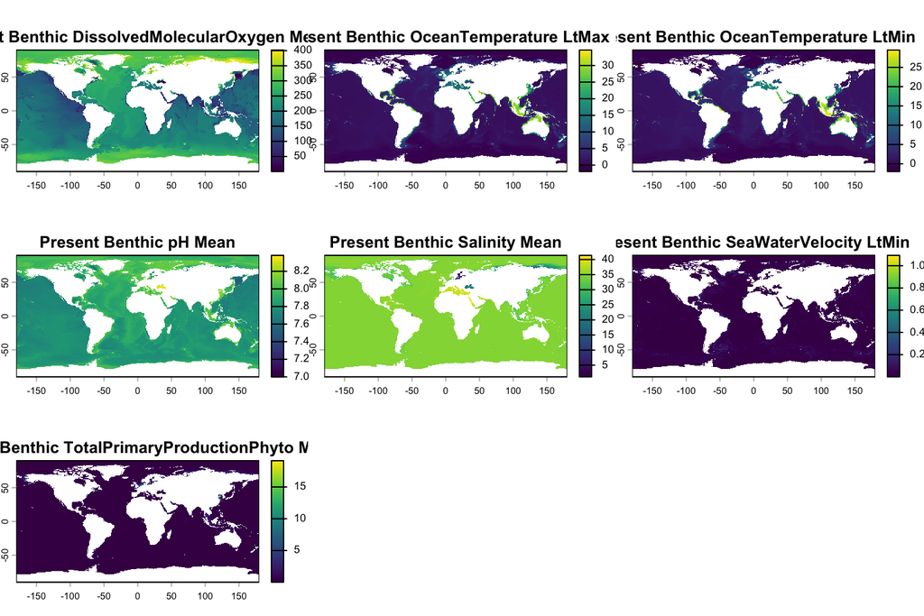

```r
# Open a raster layer with the global sea surface temperature
environmentData <- rast(myFiles)
# inspect the raster object
plot(environmentData)
```

S4 // Downloading and managing environmental data in R

## Downloading environmental data in R

biodiversityDS .

Extracting environmental layers from data warehouses such as Bio-ORACLE.

### From Bio-ORACLE

```r
# load libraries
library(biooracler)
library(bDSSDMTools)
# list available layers in Bio-ORACLE
layersList <- list_layers()
# inspect the layers
head(layersList)
```

| dataset_id | title |
| --- | --- |
| tas_baseline_2000_2020_depthsurf | Bio-Oracle AirTemperature [depthSurf] Baseline 2000-2020. |
| tas_ssp119_2020_2100_depthsurf | Bio-Oracle AirTemperature [depthSurf] SSP119 2020-2100. |
| tas_ssp126_2020_2100_depthsurf | Bio-Oracle AirTemperature [depthSurf] SSP126 2020-2100. |
| tas_ssp245_2020_2100_depthsurf | Bio-Oracle AirTemperature [depthSurf] SSP245 2020-2100. |
| tas_ssp370_2020_2100_depthsurf | Bio-Oracle AirTemperature [depthSurf] SSP370 2020-2100. |

S4 // Downloading and managing environmental data in R

biodiversityDS .

Layers can be easly downloaded using download_multiple_layers. **Main arguments** of download_multiple_layers() function:

- **variables** (list) variable name to consider (e.g., c(“thetao”, “chl”, “so”)), summary statistic derived from the variable (e.g., c(“mean”, “min”, “max”, “ltmax”)) and vertical realm (e.g., c(“depthsurf”, “depthmean”, “depthmax”)).
- **experiment** (Character) climate scenarios (e.g., c(“baseline”, “ssp126”, “ssp585”)).
- **decade** (Numeric) the start year of the specific decade (e.g., c(2020, 2050, 2090)).
- **latitude** (Numeric vector, length 2) spatial extent c(min_latitude, max_latitude).
- **longitude** (Numeric vector, length 2) spatial extent c(min_longitude, max_longitude).
- **exportRaster** (Logical, Default: TRUE) If TRUE, the function will combine layers into a single multi-layer SpatRaster.
- **directory** (Character string or NULL, Default: NULL) path to a directory. If provided, the function saves each layer as an individual **.tif** file within that directory.

Refer to the **Session-P-S04-BO-Components.html** documentation file for more details.

S4 // Downloading and managing environmental data in R

biodiversityDS .

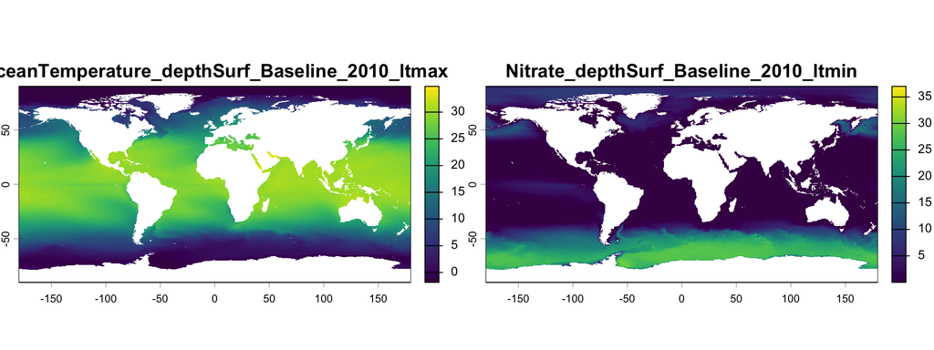

```r
# download layers
variables <- list(var1 = c("thetao", "ltmax", "depthsurf"), var2 = c("no3", "ltmin", "depthsurf"))
environmentalLayers <- download_multiple_layers(variables = variables, experiment = c("baseline"),
    decade = c(2010))
# plot layers
plot(environmentalLayers, axes = TRUE)
```

S4 // Downloading and managing environmental data in R

biodiversityDS .

#### Subsetting the a region of interest

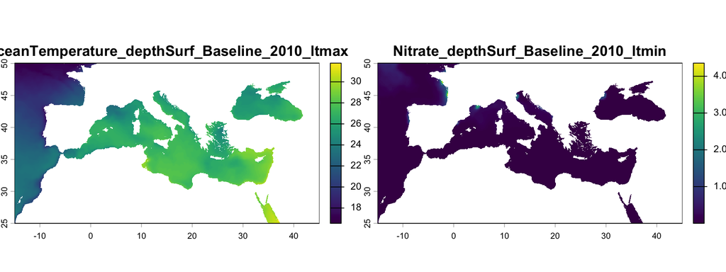

```r
# download layers
variables <- list(var1 = c("thetao", "ltmax", "depthsurf"), var2 = c("no3", "ltmin", "depthsurf"))
environmentalLayers <- download_multiple_layers(variables = variables, experiment = c("baseline"),
    decade = c(2010), longitude = c(-15, 45), latitude = c(25, 50))
# plot layers
plot(environmentalLayers, axes = TRUE)
```

S4 // Downloading and managing environmental data in R

biodiversityDS .

### Combining or comparing layers

```r
# make list of variables
variables <- list(var1 = c("thetao", "ltmax", "depthsurf"))

# download present-day layer
temperaturePresent <- download_multiple_layers(variables = variables, experiment = c("baseline"),
    decade = c(2010), longitude = c(-15, 45), latitude = c(25, 50))

# download end-of-century layer
temperatureFuture <- download_multiple_layers(variables = variables, experiment = c("ssp370"),
    decade = c(2090), longitude = c(-15, 45), latitude = c(25, 50))

# determine the degree of temperature change (anomaly)
temperatureAnomaly <- temperatureFuture - temperaturePresent
```

S4 // Downloading and managing environmental data in R

biodiversityDS .

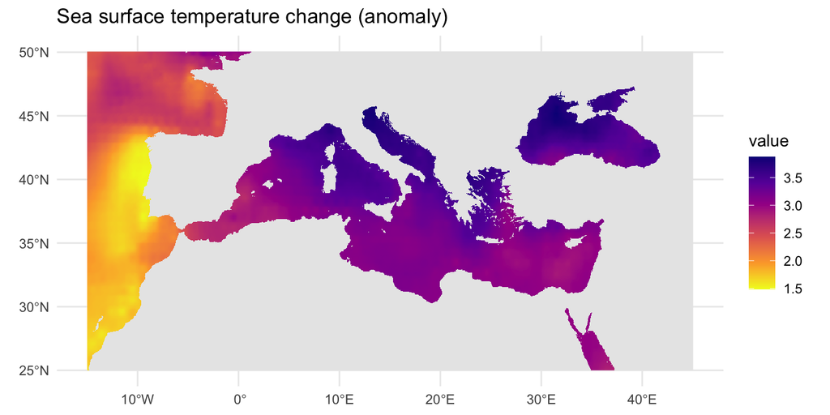

```r
# plot layer
library(ggplot2)
library(tidyterra)
ggplot() + geom_spatraster(data = temperatureAnomaly) + labs(title = "Sea surface temperature change (anomaly)") +
    scale_fill_viridis_c(option = "plasma", direction = -1, na.value = "#E8E8E8") + theme_minimal()
```

S4 // Downloading and managing environmental data in R

### Challenge 4.1

The objective of this challenge is to **extract** and plot a set of environmental layers from Bio-ORACLE.

**Packages, data and functions to accomplish the challenge:**

**Functions to use**  
library  
list_layers  
download_multiple_layers  
plot OR ggplot

S4 // Downloading and managing environmental data in R

### Challenge 4.2

The objective of this challenge is to determine the degree of temperature change along the northeast coast of the Pacific Ocean. Consider using two different decades (2010 and 2090) and two scenarios of climate change.

**Packages, data and functions to accomplish the challenge:**

**Information**  
(min longitude: -175, max longitude: -100, min latitude: 17, max latitude: 65)  
**Functions to use**  
library  
list_layers  
download_multiple_layers  
plot

S4 // Downloading and managing environmental data in R

## Downloading environmental data in R

biodiversityDS .

Extracting environmental layers from data warehouses.

#### From WorldClim

Additional information: https://wec.wur.nl/r/spatial/raster-data.html

```r
# load libraries
library(geodata)
# download available layers in WorldClim
bioPresent <- worldclim_global(var = "bio", # "tmin", "tmax", "tavg", "prec", "wind", "vapr", or "bio"
                               res = 5, # resolution: 10, 5, 2.5, or 0.5 (minutes of a degree)
                               path = "_ test")
names(bioPresent)
```

```
##  [1] "wc2.1_5m_bio_1"  "wc2.1_5m_bio_2"  "wc2.1_5m_bio_3"  "wc2.1_5m_bio_4"
##  [5] "wc2.1_5m_bio_5"  "wc2.1_5m_bio_6"  "wc2.1_5m_bio_7"  "wc2.1_5m_bio_8"
##  [9] "wc2.1_5m_bio_9"  "wc2.1_5m_bio_10" "wc2.1_5m_bio_11" "wc2.1_5m_bio_12"
## [13] "wc2.1_5m_bio_13" "wc2.1_5m_bio_14" "wc2.1_5m_bio_15" "wc2.1_5m_bio_16"
## [17] "wc2.1_5m_bio_17" "wc2.1_5m_bio_18" "wc2.1_5m_bio_19"
```

S4 // Downloading and managing environmental data in R

biodiversityDS .

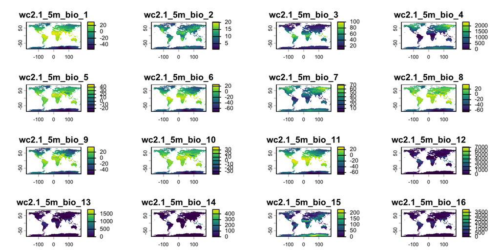

```r
# plot layers
plot(bioPresent)
```

S4 // Downloading and managing environmental data in R

biodiversityDS .

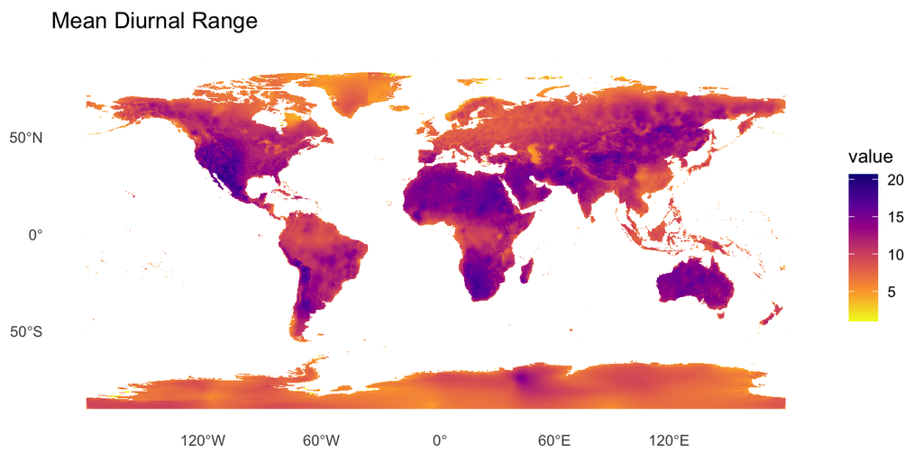

```r
# subset layers
bioPresentSubset <- bioPresent[[2]]
# plot layer
ggplot() + geom_spatraster(data = bioPresentSubset) + labs(title = "Mean Diurnal Range") + scale_fill_viridis_c(option = "plasma",
    direction = -1, na.value = "white") + theme_minimal()
```

S4 // Downloading and managing environmental data in R

biodiversityDS .

#### Future projections of environmental data can also be downloaded from WorldClim.

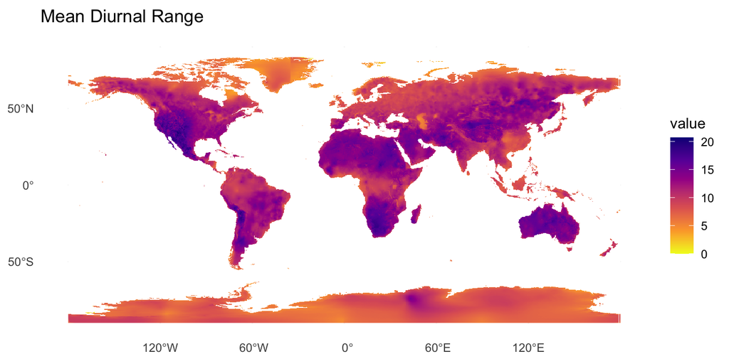

```r
# download layers
bioFuture <- cmip6_world(model = "ACCESS-ESM1-5", ssp = "245", time = "2041-2060", var = "bioc",
    download = F, res = 10, path = "_ test")

bioFutureSubset <- bioFuture[[2]]

ggplot() + geom_spatraster(data = bioFutureSubset) + labs(title = "Mean Diurnal Range") + scale_fill_viridis_c(option = "plasma",
    direction = -1, na.value = "white") + theme_minimal()
```

S4 // Downloading and managing environmental data in R